# 16S rRNA Amplicon Analysis Report

Demo project: mouse gut microbiome, early vs. late post-weaning

Jeff Keeling, Microbiome Bioinformatics

October 20, 2026

## Summary

This report covers 19 samples (9 Early, 10 Late) sequenced on the 16S rRNA V4 region (Illumina MiSeq, 2×250 bp), plus one mock community used as an accuracy control.

- **152,360 raw read pairs** were processed into **232 amplicon sequence variants (ASVs)**; a median of **81.5%** of reads per sample passed every quality step.
- **Accuracy check:** in the mock community, 20 of 20 ASVs matched a known reference strain exactly, accounting for 100.0% of mock reads.
- **Community composition differs between groups** (PERMANOVA R² = 0.43, p < 0.001), explaining about 43% of between-sample variation.
- **Within-sample diversity** does not differ significantly between groups (observed richness p = 0.094; Shannon index p = 0.111), so the groups differ in community makeup rather than in richness.
- **15 of 46 genera** differ significantly in abundance after correcting for multiple testing.

## 1. Read quality and processing

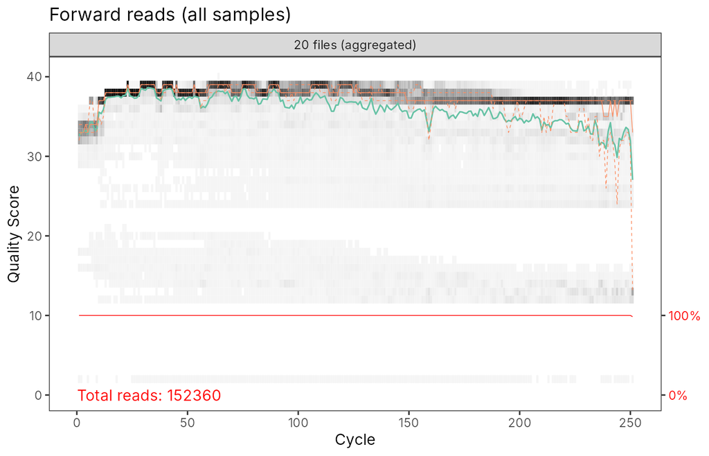

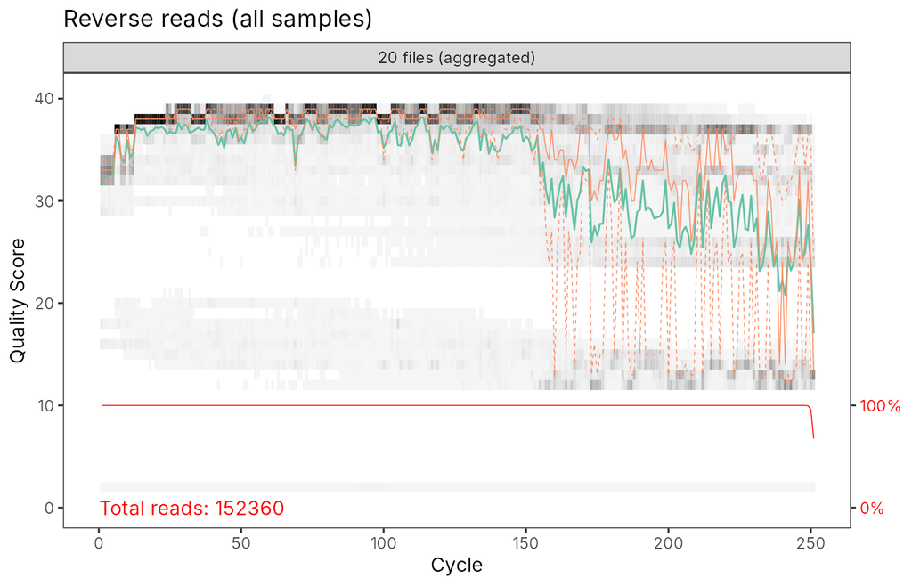

Reads were filtered (max 2 expected errors, no ambiguous bases), denoised with DADA2, merged, length-filtered to 250 to 256 bp, and screened for chimeras. Before ecological analysis, 4 off-target ASVs (mitochondrial, chloroplast, or unassigned at kingdom level; 0.13% of reads) were removed.

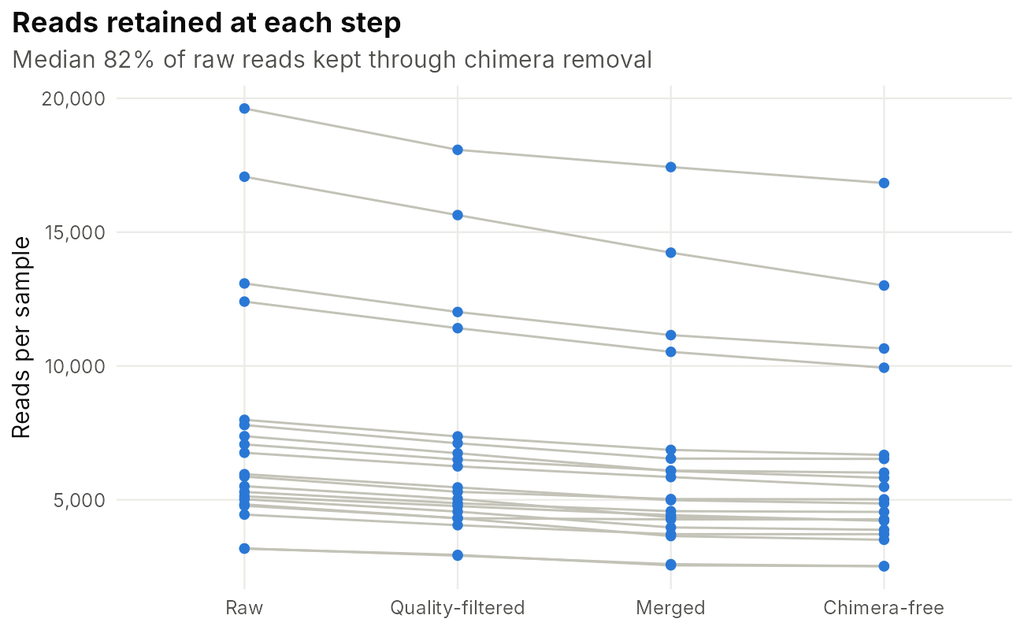

**Per-sample read counts**

| Sample | Raw | Filtered | Merged | Final | % retained |
| --- | --- | --- | --- | --- | --- |
| F3D0 | 7,793 | 7,113 | 6,540 | 6,528 | 83.8 |
| F3D141 | 5,958 | 5,463 | 4,986 | 4,863 | 81.6 |
| F3D142 | 3,183 | 2,914 | 2,595 | 2,521 | 79.2 |
| F3D143 | 3,178 | 2,941 | 2,553 | 2,519 | 79.3 |
| F3D144 | 4,827 | 4,312 | 3,646 | 3,507 | 72.7 |
| F3D145 | 7,377 | 6,741 | 6,079 | 5,820 | 78.9 |
| F3D146 | 5,021 | 4,560 | 3,968 | 3,879 | 77.3 |
| F3D147 | 17,070 | 15,637 | 14,233 | 13,006 | 76.2 |
| F3D148 | 12,405 | 11,413 | 10,528 | 9,935 | 80.1 |
| F3D149 | 13,083 | 12,017 | 11,154 | 10,653 | 81.4 |
| F3D150 | 5,509 | 5,032 | 4,349 | 4,240 | 77.0 |
| F3D1 | 5,869 | 5,299 | 5,028 | 5,017 | 85.5 |
| F3D2 | 19,620 | 18,075 | 17,431 | 16,835 | 85.8 |
| F3D3 | 6,758 | 6,250 | 5,850 | 5,486 | 81.2 |
| F3D5 | 4,448 | 4,052 | 3,716 | 3,716 | 83.5 |
| F3D6 | 7,989 | 7,369 | 6,865 | 6,678 | 83.6 |
| F3D7 | 5,129 | 4,765 | 4,426 | 4,215 | 82.2 |
| F3D8 | 5,294 | 4,871 | 4,576 | 4,547 | 85.9 |
| F3D9 | 7,070 | 6,504 | 6,092 | 6,015 | 85.1 |
| Mock | 4,779 | 4,314 | 4,269 | 4,269 | 89.3 |

## 2. Accuracy check: mock community

The mock community is a defined mix of known bacterial strains, represented by 32 reference 16S sequences. The pipeline recovered 20 ASVs from it, 20 of which match a reference sequence exactly (100.0% of mock reads). No spurious ASVs were produced, so the error-correction step is not inflating diversity.

## 3. Within-sample (alpha) diversity

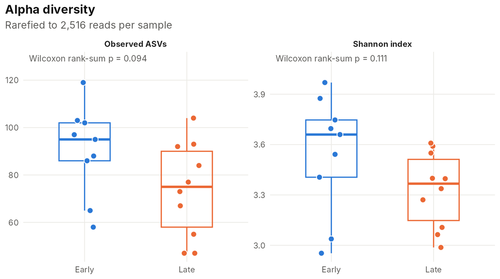

| Metric | p-value | Test |
| --- | --- | --- |
| Observed ASVs | p = 0.094 | Wilcoxon rank-sum |
| Shannon index | p = 0.111 | Wilcoxon rank-sum |

## 4. Between-sample (beta) diversity

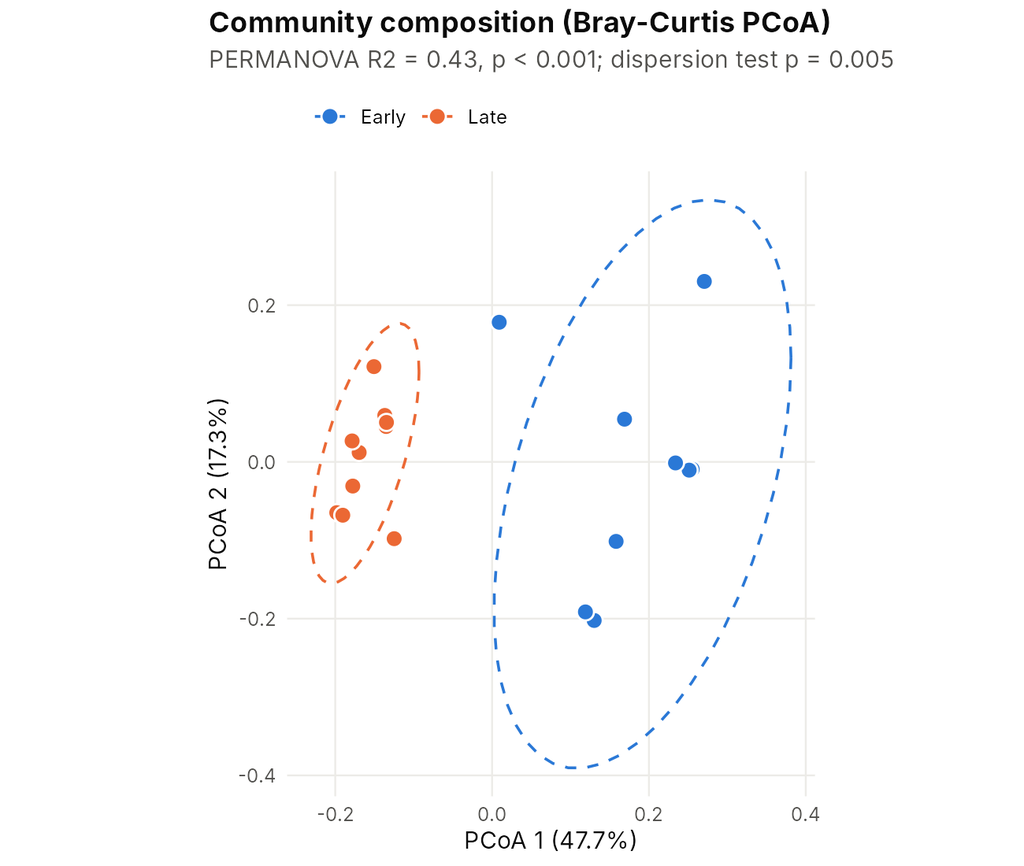

PERMANOVA on Bray-Curtis distances shows group explains **43%** of community variation (p < 0.001, 9,999 permutations). Group dispersions also differ, so part of the PERMANOVA signal may reflect differences in within-group spread; interpret with that in mind.

## 5. Taxonomic composition

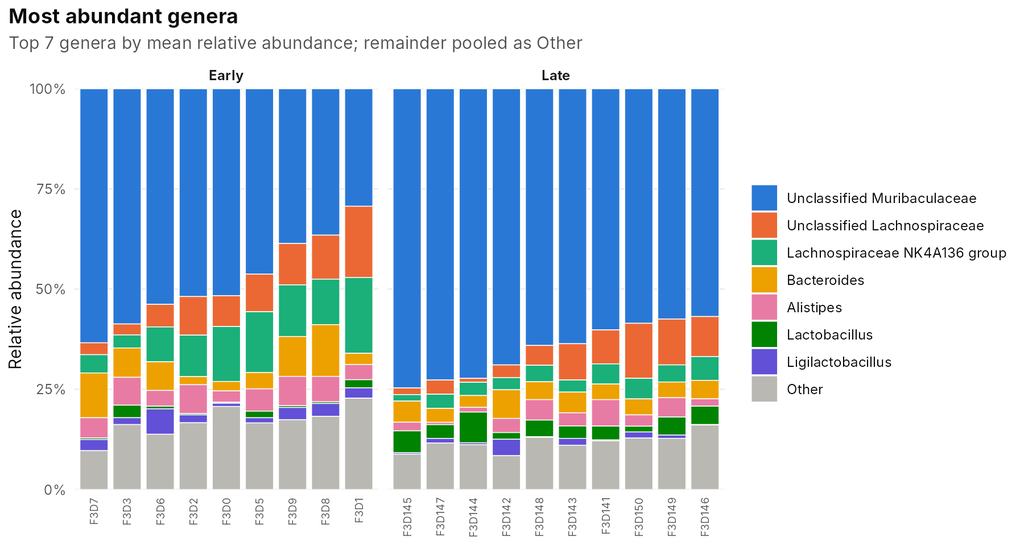

## 6. Differentially abundant genera

Genera present in at least 20% of samples were CLR-transformed and compared between groups with a Wilcoxon rank-sum test, with Benjamini-Hochberg correction.

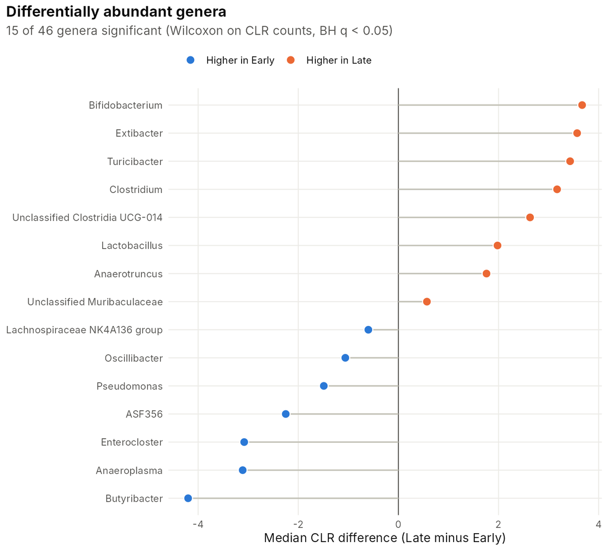

| Genus | Prevalence | Median CLR diff. | p | q (BH) |
| --- | --- | --- | --- | --- |
| Butyribacter | 0.58 | -4.20 | 0.00028 | 0.0059 |
| Enterocloster | 0.63 | -3.08 | 0.00038 | 0.0059 |
| Extibacter | 0.37 | 3.57 | 0.00038 | 0.0059 |
| Turicibacter | 0.79 | 3.43 | 0.00070 | 0.0081 |
| Lactobacillus | 1.00 | 1.98 | 0.00094 | 0.0087 |
| Anaerotruncus | 0.74 | 1.76 | 0.00220 | 0.0140 |
| Lachnospiraceae NK4A136 group | 1.00 | -0.60 | 0.00220 | 0.0140 |
| Bifidobacterium | 0.68 | 3.67 | 0.00290 | 0.0170 |
| Oscillibacter | 0.95 | -1.06 | 0.00370 | 0.0190 |
| Anaeroplasma | 0.53 | -3.11 | 0.00620 | 0.0260 |
| Clostridium | 0.53 | 3.17 | 0.00620 | 0.0260 |
| Unclassified Muribaculaceae | 1.00 | 0.57 | 0.00800 | 0.0310 |
| ASF356 | 0.37 | -2.25 | 0.01300 | 0.0450 |
| Pseudomonas | 0.47 | -1.49 | 0.01600 | 0.0490 |
| Unclassified Clostridia UCG-014 | 0.68 | 2.63 | 0.01600 | 0.0490 |

## Methods

Paired-end reads were processed in R with DADA2 (v1.30.0). Reads were truncated at 240/160 bp and filtered at maxEE = 2; error rates were learned per run and used for sample inference. Pairs were merged with a minimum 12 bp overlap, sequences outside 250 to 256 bp were removed, and chimeras were removed with the consensus method. Mitochondrial, chloroplast, and kingdom-unassigned ASVs were removed before community analysis. Taxonomy was assigned with the naive Bayesian classifier against SILVA v138.2 (minimum bootstrap 50) with exact-match species assignment. Community analyses used phyloseq (v1.46.0) and vegan (v2.6.4). Alpha diversity was computed on data rarefied to 2,516 reads per sample. Beta diversity used Bray-Curtis distances on relative abundances, tested with PERMANOVA (adonis2) and homogeneity of dispersions (betadisper), each with 9,999 permutations.

## Deliverables

| File | Contents |
| --- | --- |
| `tables/asv_counts.tsv` | ASV × sample count table |
| `tables/asv_taxonomy.tsv` | Taxonomy and sequence for each ASV |
| `asv_sequences.fasta` | ASV sequences |
| `phyloseq.rds` | Ready-to-use phyloseq object for further analysis in R |
| `tables/*.tsv` | All statistics shown in this report |
| `figures/*.png` | Publication-ready figures (200 dpi) |
| `scripts/` | Full, commented code to reproduce every result |

*Demo data: Kozich et al. (2013) Applied and Environmental Microbiology 79:5112-5120, distributed with the mothur MiSeq SOP.*